# Belief in Supernatural Evil and Guns

In this assignment we will replicate a study of belief in supernatural evil and attitudes towards guns in the United States. This assignment was done as a project for the Practical Data Science course taught by Mr. Panos Louridas at the Athens University of Economics and Business. The study to be replicated is:

Christopher G. Ellison, Benjamin Dowd-Arrow, Amy M. Burdette, Pablo E. Gonzalez, Margaret S. Kelley, Paul Froese, "Peace through superior firepower: Belief in supernatural evil and attitudes toward gun policy in the United States", Social Science Research, Volume 99, 2021, https://doi.org/10.1016/j.ssresearch.2021.102595.

The data we are going to use come from Wave Four of the Balor Religion Survey (BRS) as it is mentioned in chapter 1.4 of the paper.

> To test these hypotheses, we use data from Wave Four of the Baylor Religion Survey (BRS), which was conducted in January of 2014. Briefly, the BRS is a national random sample of 1572 non-institutionalized respondents ages 18 and over who reside in the continental United States.

With a google search for the term *Baylor Religion Survey* we find the website https://www.baylor.edu/baylorreligionsurvey/ containing the data.

[figure not shown]

We click on the data tab and then at the DATA AT THEARDA.COM button

[figure not shown]

In the page that opens up, we choose the Baylor Religion Survey, Wave IV (2014) - Instructional Dataset as it is already prepared for easier use in the classroom.

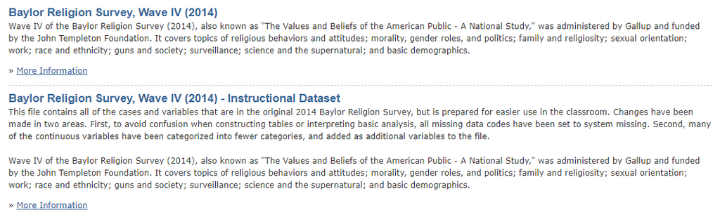

On the new page we can click the Download tab and then download the excel (.xlsx) file to our computer by first agreeing to the Privacy Policy and hitting Continue.

[figure not shown]

[figure not shown]

So, now that we have the dataset, let's import some libraries and load it.

```python
import pandas as pd
import matplotlib.pyplot as plt
%matplotlib inline
import numpy as np
import seaborn as sns
```

```python
df = pd.read_excel("Baylor Religion Survey, Wave IV (2014) - Instructional Dataset.XLSX")
```

```python
df.shape
```

```
(1572, 288)
```

```python
df.sample(10)
```

|  | MOTHERLODE_ID | PROJECT_ID | RESPONDENT_ID | METHOD_ID | METHOD_TYPE | PROJECT_NUMBER | CREATED_ON | PRACTICE | RESPONDENT_DATE | RESPONDENT_LANGUAGE | ... | LIBCONR | PARTYIDR | CHILDSR | HRSWORKD | EDUCR | I_GENDER | I_EDUC | I_MARITAL | I_RELIGION | I_ATTEND |
| --- | --- | --- | --- | --- | --- | --- | --- | --- | --- | --- | --- | --- | --- | --- | --- | --- | --- | --- | --- | --- | --- |
| 267 | 128171109 | 33370 | 01_000285_00000012 | 162048140_01 | SCAN | 162048140 | 3/26/2014 | OTHER | 1/28/2014 | en-US | ... | 3.0 | 2.0 | NaN | 0.0 | 1.0 | 1.0 | 1.0 | 1.0 | 1.0 | 6.0 |
| 464 | 128171905 | 33370 | 01_000482_00000020 | 162048140_01 | SCAN | 162048140 | 3/26/2014 | OTHER | 1/28/2014 | en-US | ... | 1.0 | 1.0 | 3.0 | 3.0 | 3.0 | 2.0 | 3.0 | 2.0 | 5.0 | 6.0 |
| 1269 | 128172732 | 33370 | 01_001468_00000059 | 162048140_01 | SCAN | 162048140 | 3/26/2014 | OTHER | 2/25/2014 | en-US | ... | 2.0 | 1.0 | 1.0 | 1.0 | 4.0 | 2.0 | 5.0 | 2.0 | 2.0 | 6.0 |
| 484 | 128171911 | 33370 | 01_000502_00000021 | 162048140_01 | SCAN | 162048140 | 3/26/2014 | OTHER | 1/28/2014 | en-US | ... | 3.0 | 3.0 | NaN | 2.0 | 2.0 | 1.0 | 2.0 | 4.0 | 3.0 | 3.0 |
| 219 | 128171078 | 33370 | 01_000237_00000010 | 162048140_01 | SCAN | 162048140 | 3/26/2014 | OTHER | 1/28/2014 | en-US | ... | 1.0 | 1.0 | 1.0 | 4.0 | 2.0 | 1.0 | 2.0 | 4.0 | 1.0 | 3.0 |
| 1173 | 128171675 | 33370 | 01_001305_00000053 | 162048140_01 | SCAN | 162048140 | 3/26/2014 | OTHER | 2/19/2014 | en-US | ... | 2.0 | 2.0 | 1.0 | 4.0 | 3.0 | 1.0 | 4.0 | 2.0 | 4.0 | 4.0 |
| 841 | 128171493 | 33370 | 01_000885_00000036 | 162048140_01 | SCAN | 162048140 | 3/26/2014 | OTHER | 2/4/2014 | en-US | ... | 2.0 | 3.0 | NaN | 3.0 | NaN | 2.0 | NaN | 2.0 | 1.0 | 6.0 |
| 1524 | 128172319 | 33370 | 01_001830_00000074 | 162048140_01 | SCAN | 162048140 | 3/26/2014 | OTHER | 3/21/2014 | en-US | ... | 1.0 | 1.0 | 1.0 | 5.0 | 3.0 | 1.0 | 3.0 | 3.0 | 1.0 | 3.0 |
| 1245 | 128172716 | 33370 | 01_001411_00000057 | 162048140_01 | SCAN | 162048140 | 3/26/2014 | OTHER | 2/21/2014 | en-US | ... | 1.0 | 2.0 | NaN | 0.0 | NaN | 2.0 | NaN | 2.0 | 4.0 | 3.0 |
| 286 | 128171126 | 33370 | 01_000304_00000013 | 162048140_01 | SCAN | 162048140 | 3/26/2014 | OTHER | 1/28/2014 | en-US | ... | 1.0 | 1.0 | 2.0 | NaN | 3.0 | 2.0 | 3.0 | 2.0 | 4.0 | 3.0 |

10 rows × 288 columns

To understand the columns we refer to the Codebook of the dataset that can be found [here](https://www.thearda.com/Archive/Files/Codebooks/BRS2014ED_CB.asp).

## Questions

### Q1: Belief in Supernatural Evil Metric

In order to measure the belief in supernatural evil, we will use the answers to three questions asked by the participants in the survey:

- Whether the respondent believes in the devil.
- Whether the respondent believes in hell.
- Whether the respondent believes in demons.

You will investigate how the answers to these three questions can be combined to a single metric. Justify your approach.

Based on the Codebook the answers to the above questions are in columns Q23A, Q23C and Q23G for belief in devil, hell and demons respectively. The response categories for each item were:

1 = Absolutely not  
2 = Probably not  
3 = Probably  
4 = Absolutely

We will follow the paper's approach that is indeed logical. Responses to the three items are summed and averaged across the number of items answered to create the index we need.

```python
df[['Q23A', 'Q23C', 'Q23G']].isna().sum()
```

```
Q23A    68
Q23C    73
Q23G    80
dtype: int64
```

```python
df[['Q23A', 'Q23C', 'Q23G']]
```

|  | Q23A | Q23C | Q23G |
| --- | --- | --- | --- |
| 0 | 4.0 | 4.0 | 4.0 |
| 1 | 4.0 | 4.0 | 4.0 |
| 2 | 3.0 | 2.0 | 2.0 |
| 3 | 4.0 | 4.0 | 4.0 |
| 4 | 4.0 | 4.0 | 4.0 |
| ... | ... | ... | ... |
| 1567 | 4.0 | 2.0 | 4.0 |
| 1568 | 3.0 | 3.0 | 3.0 |
| 1569 | 4.0 | 4.0 | 3.0 |
| 1570 | 3.0 | 3.0 | 3.0 |
| 1571 | NaN | NaN | NaN |

1572 rows × 3 columns

```python
df[df['Q23A'].isna()][['Q23A', 'Q23C', 'Q23G']]
```

|  | Q23A | Q23C | Q23G |
| --- | --- | --- | --- |
| 53 | NaN | NaN | NaN |
| 115 | NaN | NaN | NaN |
| 141 | NaN | NaN | NaN |
| 166 | NaN | NaN | NaN |
| 169 | NaN | NaN | NaN |
| ... | ... | ... | ... |
| 1538 | NaN | NaN | 4.0 |
| 1542 | NaN | NaN | NaN |
| 1556 | NaN | NaN | 4.0 |
| 1560 | NaN | NaN | NaN |
| 1571 | NaN | NaN | NaN |

68 rows × 3 columns

We have some NaN values in the above fields. We aren't going to fill them yet because we see that there are questions that are answered in the same line that there are NaN so we are going to take the mean across the rows. The mean will disregard the NaN in the rows that have at least one value. This will create values for our focal variable even if one or two values are missing from the line. Also, looking at the values I notice that most scores stay almost the same across these questions for the same individual so it's a good reasoning that the mean will in fact fill them with the mean of the columns that have values.

After creating the supernatural evil column we will have some NaN values that we will fill with the mean across columns.

```python
df['Supernatural Evil'] = df[['Q23A', 'Q23C', 'Q23G']].mean(axis=1)
```

```python
df['Supernatural Evil'].isna().sum()
```

```
55
```

We are left with only 55 NaN values. We will fill them with the mean.

```python
df['Supernatural Evil'].mean()
```

```
3.089540760272468
```

The mean of our new variable is 3.09 rounded to 2 decimals as it is the case in the paper.

```python
df['Supernatural Evil'].fillna(df['Supernatural Evil'].mean(), inplace=True)
```